# Support Vector Machine

MAKINI CALEB

2026-10-05

# SETTING A WORKING DIRECTORY

```r
setwd("C:/Users/ADMIN/OneDrive/Desktop/caleb makini")
```

# load libraries

```r
library(dplyr)
library(tidyverse)
library(e1071)
library(caret)
library(psych)
library(ggplot2)
```

# support vector machine(SVM)

- is a suppervised machine learning algorthm used for both classification and regression task.
- svm woks by finding optimal boundary (hyperplane) that best separates data points into different classes while maximising the margin btn them

# load data set

```r
data(mtcars)
head(data)
```

[output not shown]

# check structure

```r
str(mtcars)
```

```
'data.frame':   32 obs. of  11 variables:
 $ mpg : num  21 21 22.8 21.4 18.7 18.1 14.3 24.4 22.8 19.2 ...
 $ cyl : num  6 6 4 6 8 6 8 4 4 6 ...
 $ disp: num  160 160 108 258 360 ...
 $ hp  : num  110 110 93 110 175 105 245 62 95 123 ...
 $ drat: num  3.9 3.9 3.85 3.08 3.15 2.76 3.21 3.69 3.92 3.92 ...
 $ wt  : num  2.62 2.88 2.32 3.21 3.44 ...
 $ qsec: num  16.5 17 18.6 19.4 17 ...
 $ vs  : num  0 0 1 1 0 1 0 1 1 1 ...
 $ am  : num  1 1 1 0 0 0 0 0 0 0 ...
 $ gear: num  4 4 4 3 3 3 3 4 4 4 ...
 $ carb: num  4 4 1 1 2 1 4 2 2 4 ...
```

# summary statistics

```r
describe(mtcars)
```

```
     vars  n   mean     sd median trimmed    mad   min    max  range  skew
mpg     1 32  20.09   6.03  19.20   19.70   5.41 10.40  33.90  23.50  0.61
cyl     2 32   6.19   1.79   6.00    6.23   2.97  4.00   8.00   4.00 -0.17
disp    3 32 230.72 123.94 196.30  222.52 140.48 71.10 472.00 400.90  0.38
hp      4 32 146.69  68.56 123.00  141.19  77.10 52.00 335.00 283.00  0.73
drat    5 32   3.60   0.53   3.70    3.58   0.70  2.76   4.93   2.17  0.27
wt      6 32   3.22   0.98   3.33    3.15   0.77  1.51   5.42   3.91  0.42
qsec    7 32  17.85   1.79  17.71   17.83   1.42 14.50  22.90   8.40  0.37
vs      8 32   0.44   0.50   0.00    0.42   0.00  0.00   1.00   1.00  0.24
am      9 32   0.41   0.50   0.00    0.38   0.00  0.00   1.00   1.00  0.36
gear   10 32   3.69   0.74   4.00    3.62   1.48  3.00   5.00   2.00  0.53
carb   11 32   2.81   1.62   2.00    2.65   1.48  1.00   8.00   7.00  1.05
     kurtosis    se
mpg     -0.37  1.07
cyl     -1.76  0.32
disp    -1.21 21.91
hp      -0.14 12.12
drat    -0.71  0.09
wt      -0.02  0.17
qsec     0.34  0.32
vs      -2.00  0.09
am      -1.92  0.09
gear    -1.07  0.13
carb     1.26  0.29
```

# check missing values

```r
colSums((is.na(mtcars)))
```

```
 mpg  cyl disp   hp drat   wt qsec   vs   am gear carb
   0    0    0    0    0    0    0    0    0    0    0
```

# split data

```r
set.seed(123)
split_index <- createDataPartition(mtcars$mpg, p = 0.8, list = FALSE)
train_data1 <- mtcars[split_index, ]
test_data1 <- mtcars[-split_index, ]
```

# data dimension

```r
dim(train_data1)
```

```
[1] 28 11
```

```r
dim(test_data1)
```

```
[1]  4 11
```

# scale the predictor valiables

```r
x_train <- train_data1[, -1]
y_train <- train_data1$mpg
x_test <- test_data1[, -1]
y_test <- test_data1$mpg
preProc <- preProcess(x_train, method = c("center", "scale"))
x_train_scaled <- predict(preProc, x_train)
x_test_scaled <- predict(preProc, x_test)
```

# train SVM model

```r
svm_model <- svm(x = x_train_scaled, y = y_train, type = "eps-regression", kernel = "radial")
print(svm_model)
```

```
Call:
svm.default(x = x_train_scaled, y = y_train, type = "eps-regression",
    kernel = "radial")


Parameters:
   SVM-Type:  eps-regression
 SVM-Kernel:  radial
       cost:  1
      gamma:  0.1
    epsilon:  0.1


Number of Support Vectors:  27
```

# make predictions

```r
predictions <- predict(svm_model, newdata = x_test_scaled)
```

# evaluate model performance

### rmse

```r
rmse <- sqrt(mean((predictions - y_test)^2))
rmse
```

```
[1] 3.699094
```

## mae

```r
mae <- mean(abs(predictions - y_test))
mae
```

```
[1] 2.58204
```

### r2

```r
R2 = cor(predictions, y_test)^2
R2
```

```
[1] 0.978711
```

## actual vs predicted values

```r
results <- data.frame(actual = y_test, predicted = round(predictions, 2))
results
```

```
               actual predicted
Mazda RX4 Wag    21.0     20.46
Duster 360       14.3     15.23
Toyota Corolla   33.9     26.79
Ford Pantera L   15.8     17.56
```

### scatterplot of predictions

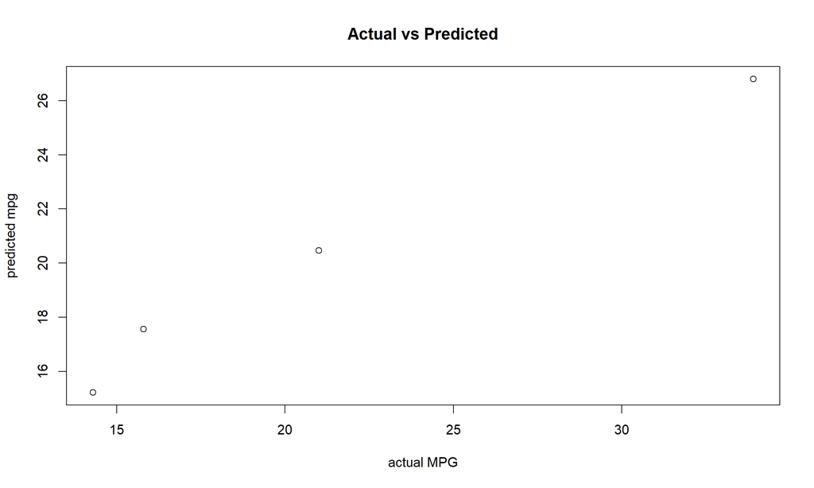

```r
plot(y_test, predictions, main = "Actual vs Predicted", xlab = "actual MPG", ylab = "predicted mpg")
```

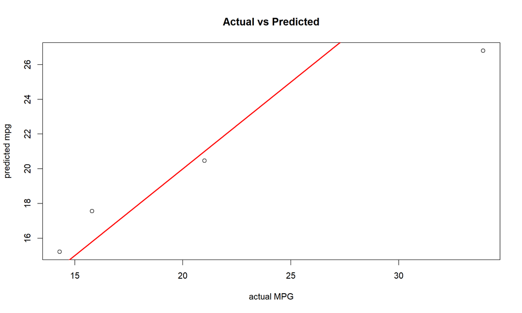

```r
abline(0, 1, col = "red", lwd = 2)
```

## hyperparamater tuning for better accuracy

```r
set.seed(123)
turned_model <- tune(svm, mpg ~ ., data = train_data1, kernel = "radial", ranges = list(cost = c(0.1,
    1, 10, 100), gamma = c(0.001, 0.01, 0.1, 1)))
summary(turned_model)
```

```
Parameter tuning of 'svm':

- sampling method: 10-fold cross validation

- best parameters:
 cost gamma
  100 0.001

- best performance: 9.829934

- Detailed performance results:
    cost gamma     error dispersion
1    0.1 0.001 37.207595  46.465331
2    1.0 0.001 26.084064  35.232023
3   10.0 0.001  9.967809  15.034870
4  100.0 0.001  9.829934  11.250340
5    0.1 0.010 28.126860  37.680298
6    1.0 0.010 11.118237  16.296164
7   10.0 0.010 10.959620  12.349576
8  100.0 0.010 15.020004   9.349671
9    0.1 0.100 24.267188  34.201221
10   1.0 0.100 15.641217  20.443995
11  10.0 0.100 13.658459  14.380619
12 100.0 0.100 23.175968  28.441952
13   0.1 1.000 34.430218  43.184000
14   1.0 1.000 21.652496  28.751322
15  10.0 1.000 18.339938  23.208573
16 100.0 1.000 18.339938  23.208573
```

## best model

```r
best_svm <- turned_model$best.model
pred_best <- predict(best_svm, test_data1)
rmse_best <- sqrt(mean((pred_best - test_data1$mpg)^2))
mae_best <- mean(abs(pred_best - test_data1$mpg))
rmse_best
```

```
[1] 3.815788
```

```r
mae_best
```

```
[1] 2.733657
```

# SVM CLASSIFICATION

```r
data(iris)
set.seed(123)
train_data2 <- createDataPartition(iris$Species, p = 0.8, list = FALSE)
train <- iris[train_data2, ]
test <- iris[-train_data2, ]
svm_classifier <- svm(Species ~ ., data = train, kernel = "radial")
pred_class <- predict(svm_classifier, test)
confusionMatrix(pred_class, test$Species)
```

```
Confusion Matrix and Statistics

            Reference
Prediction   setosa versicolor virginica
  setosa         10          0         0
  versicolor      0         10         2
  virginica       0          0         8

Overall Statistics

               Accuracy : 0.9333
                 95% CI : (0.7793, 0.9918)
    No Information Rate : 0.3333
    P-Value [Acc > NIR] : 8.747e-12

                  Kappa : 0.9

 Mcnemar's Test P-Value : NA

Statistics by Class:

                     Class: setosa Class: versicolor Class: virginica
Sensitivity                 1.0000            1.0000           0.8000
Specificity                 1.0000            0.9000           1.0000
Pos Pred Value              1.0000            0.8333           1.0000
Neg Pred Value              1.0000            1.0000           0.9091
Prevalence                  0.3333            0.3333           0.3333
Detection Rate              0.3333            0.3333           0.2667
Detection Prevalence        0.3333            0.4000           0.2667
Balanced Accuracy           1.0000            0.9500           0.9000
```

- TP = true positive for that class.
- TN = true negative for that class.
- FP = false positive for that class.
- FN = false negative for that class.
- N = total number of samples.
- Sensitivity: TP / (TP + FN). Of all real members of this class, how many did the model catch?
- Specificity: TN / (TN + FP). Of all real non-members, how many did the model correctly reject?
- Pos Pred Value: TP / (TP + FP). When the model predicts this class, how often is it correct?
- Neg Pred Value: TN / (TN + FN). When the model predicts “not this class,” how often is it correct?
- Prevalence: (TP + FN) / N. How common is this class in the actual data?
- Detection Rate: TP / N. What fraction of all samples are correctly predicted as this class?
- Detection Prevalence: (TP + FP) / N. What fraction of all samples are predicted as this class, right or wrong?
- Balanced Accuracy: (Sensitivity + Specificity) / 2. Fair average of catching real cases and avoiding false alarms.

# explanation on results above

- setosa: all metrics are 1.0000, so it is perfectly classified.
- versicolor: Sensitivity = 1.0000, so all real versicolor were caught.
- versicolor: Specificity = 0.9000, so some non-versicolor were wrongly called versicolor.
- versicolor: Pos Pred Value = 0.8333, so only 83.33% of versicolor predictions were correct.
- virginica: Sensitivity = 0.8000, so 20% of real virginica were missed.
- virginica: Specificity = 1.0000, so no other class was wrongly called virginica.
- virginica: Neg Pred Value = 0.9091, so some real virginica were predicted as “not virginica.”
- Balanced Accuracy: setosa = 1.0000, versicolor = 0.9500, virginica = 0.9000.